# Practical Machine Learning Project

vnkt

Monday, February 16, 2015

### Introduction

Using activity tracking devices it becomes increasingly possible to collect a large amount of data about personal activity. One thing that people regularly do is quantify how much of a particular activity they do, but they rarely quantify how well they do it. In this project, the goal will be to use data from accelerometers on the belt, forearm, arm, and dumbell of 6 participants, asked to perform barbell lifts correctly and incorrectly in 5 different ways.

### Executive summary

Using data described below, we’ll show that predicting the quality of the physically excersise is indeed possible. Several models have been built before indentifying the one delivering highest accuracy. The final model predicts with 99% accuracy the outcome on a 30% validation set. Further, the model is applied on 20 test cases and they were submitted for grading.

### Data sets

The data on which this analysis is described on the original study page [here] (http://groupware.les.inf.puc-rio.br/har#weight_lifting_exercises)

*Please note that the data should be first downloaded and placed in your working directory inorder for the code to run.*

### Reading the data

First data packages will be loaded used in the code. Then the raw data is read taking into account some values indicating missing values.

```r
library(data.table); library(caret); library(rattle); library(randomForest)
training <- read.csv("pml-training.csv", na.strings=c("NA","#DIV/0!",""))
testing <- read.csv("pml-testing.csv", na.strings=c("NA","#DIV/0!",""))
```

### Data preprocessing

- Running the `summary(training)` command shows that there are quite a few variable with many NA’s(missing values). As this might have negatve impact on running machine learning models, those variables will be dropped out both from the training and testin data sets.
- Addtionaly, variables not considered predictors will also be removed (timestamps, user names etc.)
- And finally variables with near zero variance will also be dropped

```r
# List of vars to keep : Complete cases
    keep <- colnames(training)[complete.cases(t(training))]
# List of vars to keep : drop non-relevant vars
    keep <- keep[keep != c("X", "user_name", keep[grepl("timestamp", keep)])]
# List of vars to keep : drop nzv vars
    NZV <- nearZeroVar(training, saveMetrics=TRUE)
    keep <-keep[!(keep %in% rownames(NZV[NZV$nzv,]))]
# Trim the data
    training <- training[keep]
```

### Cross-validation / Partition the data

Cross-validation will be done by splitting randomly the data into training data (70%) of the original and testing data (30%). The models produced on the training subset will be evaluated on the testing set.

```r
set.seed(123)
inTrain <- createDataPartition(y=training$classe, p=0.7, list=FALSE)
TRN <- training[inTrain, ]; TST <- training[-inTrain, ]
dim(training); dim(TRN); dim(TST)
```

```
## [1] 19622    54
```

```
## [1] 13737    54
```

```
## [1] 5885   54
```

### Model 1: A Decision Tree Model

Using the `rpart` method a decision tree model will be first built.

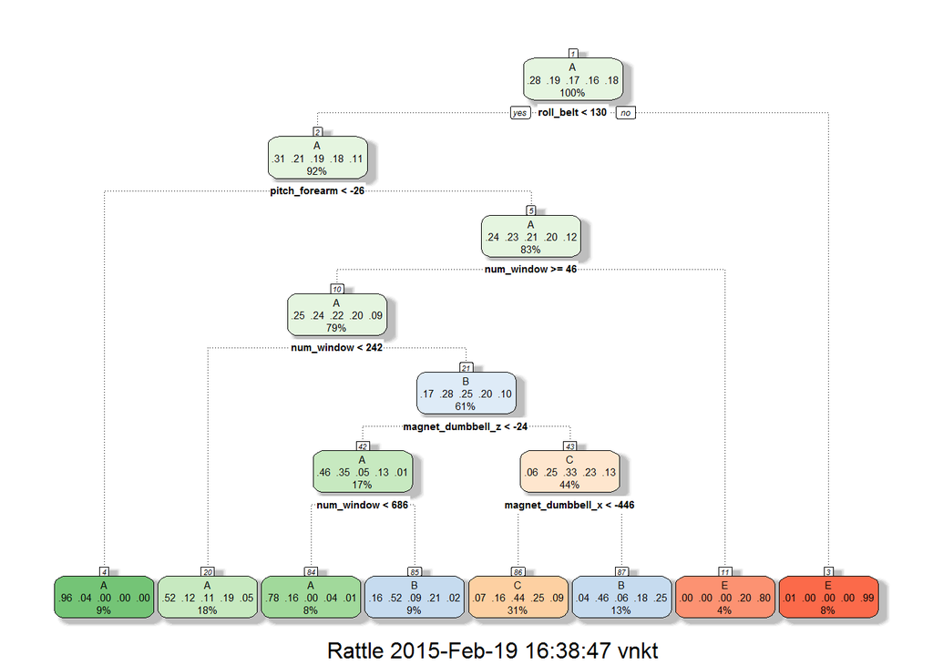

#### Validating Model 1 on the test sample

```r
predictions <- predict(modelFit, newdata=TST)
confusionMatrix(predictions, TST$classe)
```

```
## Confusion Matrix and Statistics
##
##           Reference
## Prediction    A    B    C    D    E
##          A 1450  239  114  221   63
##          B  116  616  104  241  206
##          C  101  284  808  458  165
##          D    0    0    0    0    0
##          E    7    0    0   44  648
##
## Overall Statistics
##
##                Accuracy : 0.5985
##                  95% CI : (0.5858, 0.611)
##     No Information Rate : 0.2845
##     P-Value [Acc > NIR] : < 2.2e-16
##
##                   Kappa : 0.4861
##  Mcnemar's Test P-Value : < 2.2e-16
##
## Statistics by Class:
##
##                      Class: A Class: B Class: C Class: D Class: E
## Sensitivity            0.8662   0.5408   0.7875   0.0000   0.5989
## Specificity            0.8487   0.8595   0.7925   1.0000   0.9894
## Pos Pred Value         0.6948   0.4801   0.4449      NaN   0.9270
## Neg Pred Value         0.9410   0.8864   0.9464   0.8362   0.9163
## Prevalence             0.2845   0.1935   0.1743   0.1638   0.1839
## Detection Rate         0.2464   0.1047   0.1373   0.0000   0.1101
## Detection Prevalence   0.3546   0.2180   0.3086   0.0000   0.1188
## Balanced Accuracy      0.8575   0.7001   0.7900   0.5000   0.7941
```

The decision tree model shows very poor performance as indicated by the Accuracy rate of 0.5985.

### Model 2: A Decision Tree Model with prepocessing

A second model will be built, again as decision tree, only this time pre-proceced data will be used as input using the principal component method.

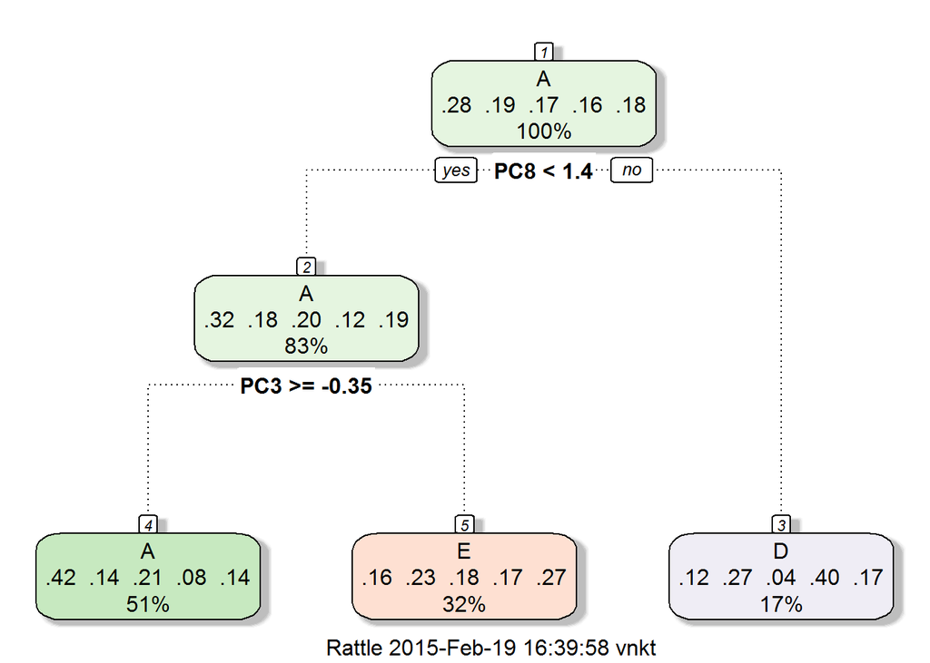

#### Validating Model 2 on the (preprocessed) test sample

```r
TST.PCA <- predict(preProc, TST[,-length(TST)] )

predictions <- predict(modelFit, newdata=TST.PCA)
confusionMatrix(predictions, TST$classe)
```

```
## Confusion Matrix and Statistics
##
##           Reference
## Prediction    A    B    C    D    E
##          A 1234  423  671  278  394
##          B    0    0    0    0    0
##          C    0    0    0    0    0
##          D  118  270   44  362  190
##          E  322  446  311  324  498
##
## Overall Statistics
##
##                Accuracy : 0.3558
##                  95% CI : (0.3436, 0.3682)
##     No Information Rate : 0.2845
##     P-Value [Acc > NIR] : < 2.2e-16
##
##                   Kappa : 0.1615
##  Mcnemar's Test P-Value : NA
##
## Statistics by Class:
##
##                      Class: A Class: B Class: C Class: D Class: E
## Sensitivity            0.7372   0.0000   0.0000  0.37552  0.46026
## Specificity            0.5806   1.0000   1.0000  0.87360  0.70789
## Pos Pred Value         0.4113      NaN      NaN  0.36789  0.26197
## Neg Pred Value         0.8475   0.8065   0.8257  0.87717  0.85341
## Prevalence             0.2845   0.1935   0.1743  0.16381  0.18386
## Detection Rate         0.2097   0.0000   0.0000  0.06151  0.08462
## Detection Prevalence   0.5098   0.0000   0.0000  0.16720  0.32302
## Balanced Accuracy      0.6589   0.5000   0.5000  0.62456  0.58407
```

This model shows even lower performance. Accuracy rate is 0.3558. This route will be abandoned and a model built with other methods will be attempted.

### Model 3: Random Forest

The model is run using the default parameters.

#### Validating Model 3 on the test sample

```r
predictions <- predict(modelFit, newdata=TST)
confusionMatrix(predictions, TST$classe)
```

```
## Confusion Matrix and Statistics
##
##           Reference
## Prediction    A    B    C    D    E
##          A 1674    1    0    0    0
##          B    0 1138    8    0    0
##          C    0    0 1018    6    0
##          D    0    0    0  957    0
##          E    0    0    0    1 1082
##
## Overall Statistics
##
##                Accuracy : 0.9973
##                  95% CI : (0.9956, 0.9984)
##     No Information Rate : 0.2845
##     P-Value [Acc > NIR] : < 2.2e-16
##
##                   Kappa : 0.9966
##  Mcnemar's Test P-Value : NA
##
## Statistics by Class:
##
##                      Class: A Class: B Class: C Class: D Class: E
## Sensitivity            1.0000   0.9991   0.9922   0.9927   1.0000
## Specificity            0.9998   0.9983   0.9988   1.0000   0.9998
## Pos Pred Value         0.9994   0.9930   0.9941   1.0000   0.9991
## Neg Pred Value         1.0000   0.9998   0.9984   0.9986   1.0000
## Prevalence             0.2845   0.1935   0.1743   0.1638   0.1839
## Detection Rate         0.2845   0.1934   0.1730   0.1626   0.1839
## Detection Prevalence   0.2846   0.1947   0.1740   0.1626   0.1840
## Balanced Accuracy      0.9999   0.9987   0.9955   0.9964   0.9999
```

The random forest model is far superior than the previously run models judged by the cross-validation accuracy. As the accuracy is sufficiently high (Accuracy rate of .997) no further models will be tested.

```r
myFinaModel <-modelFit
```

### Expected Out of Sample Error

The expected out-of-sample error is defined as 1-accuracy ration from the cross-validation data. Accuracy itself is the share of correct classified cases over the total number of cases in the testing data. As the cross-validation procedure is run on a test set that was untouched during training the model, the out-of sample error obtained on the test set should be ab unbiased estimate of the model’s accuracy. The final model built to predict the quality of the exercise has an accuracy rate of 0.997, when applied on the test sample. That means that the estimated out-of sample-error is (1-0.997) is 0.003 or 0.3%.

##### Predict the 20 test cases and export the files to be uploaded

```r
answers = predict(myFinaModel, newdata=testing)

pml_write_files = function(x){
  n = length(x)
  for(i in 1:n){
    filename = paste0("problem_id_",i,".txt")
    write.table(x[i],file=filename,quote=FALSE,row.names=FALSE,col.names=FALSE)
  }
}

pml_write_files(answers)

#file.copy("pml.html", "index.html", overwrite=TRUE)
```